# Feature engineering

Task: To predict students’ eventual course outcomes based on the data about their interaction with online course activities during the first few weeks of the course

Rationale: To be able to timely warn students who are at the risk of having low course outcome

Data set: The data used below is an adapted (simplified) version of the publicly available [Moodle Learning Analytics data set](https://github.com/sonsoleslp/labook-data/tree/main/1_moodleLAcourse)

Load the required R packages (additional ones will be loaded as needed)

```r
library(ggplot2)
library(dplyr)

data_dir = "data"
```

## Exploratory data analysis

## Load the data

We have two data sets, one with logged events data and the other with the student grades

```r
events = read.csv(paste(data_dir, "events.csv", sep='/'))
grades = read.csv(paste(data_dir, "grades.csv", sep = '/'))
```

```r
glimpse(events)
```

```
Rows: 95,626
Columns: 3
$ user   <chr> "9d744e5bf", "91489f7a9", "278a75edf", "53d6ab60c", "aab7ad69f", "82ed5d2d3", "…
$ action <chr> "Assignment", "Assignment", "Assignment", "Assignment", "Assignment", "Assignme…
$ ts     <chr> "2019-10-26 09:37:12", "2019-10-26 09:09:34", "2019-10-18 12:05:28", "2019-10-1…
```

```r
glimpse(grades)
```

```
Rows: 130
Columns: 2
$ user  <chr> "6eba3ff82", "05b604102", "111422ee7", "b4658c3a9", "e6ec47f29", "56dc40445", "b…
$ grade <dbl> 2.626970, 4.670169, 9.244600, 0.000000, 8.238179, 5.604203, 5.096322, 8.293053, …
```

Note that based on the data set as originally given, we cannot make predictions about student course outcomes: the only variables we have are `action` and `ts` and these - in the given form - cannot be used for any meaningful prediction. So, we have to create (‘engineer’) new features that will be used for the prediction task.

### Explore logged events

We will first focus on the time stamps (datetime) data and explore how we can make use of it

```r
events$ts[1:10]
```

```
 [1] "2019-10-26 09:37:12" "2019-10-26 09:09:34" "2019-10-18 12:05:28" "2019-10-19 13:28:37"
 [5] "2019-10-15 23:38:13" "2019-10-18 17:51:43" "2019-10-18 15:22:56" "2019-10-22 13:46:51"
 [9] "2019-10-15 14:58:17" "2019-10-19 13:28:38"
```

To handle datetime data easily and effectively, we will use the [`lubridate` R package](https://lubridate.tidyverse.org/)

```r
library(lubridate)
```

Let’s start by transforming time stamp data, from char format, to the R’s format suitable for working with date and time

```r
?parse_date_time
```

```r
ev1 = parse_date_time(events$ts[1], "ymd HMS")
ev1
```

```
[1] "2019-10-26 09:37:12 UTC"
```

```r
class(ev1)
```

```
[1] "POSIXct" "POSIXt"
```

Note that `POSIXct` is the native R’s format for representing date and time and it stores datetime data as the number of seconds from January 1st, 1970, the so-called [Unix timestamp](https://www.unixtimestamp.com/).

```r
ev2 = parse_date_time(events$ts[2], "ymd HMS")
ev1 - ev2
```

```
Time difference of 27.63333 mins
```

```r
class(ev1 - ev2)
```

```
[1] "difftime"
```

An alternative is to use functions specialised for some commonly used datetime formats - for example, for the above one, we could have used the `ymd_hms()` function:

```r
ymd_hms(events$ts[1])
```

```
[1] "2019-10-26 09:37:12 UTC"
```

Now, apply it to the entire column with the timestamp data:

```r
events$dt = parse_date_time(events$ts, "ymd HMS")
```

```r
events[1:10, c("ts","dt")]
```

|  | ts | dt |
| --- | --- | --- |
| 1 | 2019-10-26 09:37:12 | 2019-10-26 09:37:12 |
| 2 | 2019-10-26 09:09:34 | 2019-10-26 09:09:34 |
| 3 | 2019-10-18 12:05:28 | 2019-10-18 12:05:28 |
| 4 | 2019-10-19 13:28:37 | 2019-10-19 13:28:37 |
| 5 | 2019-10-15 23:38:13 | 2019-10-15 23:38:13 |
| 6 | 2019-10-18 17:51:43 | 2019-10-18 17:51:43 |
| 7 | 2019-10-18 15:22:56 | 2019-10-18 15:22:56 |
| 8 | 2019-10-22 13:46:51 | 2019-10-22 13:46:51 |
| 9 | 2019-10-15 14:58:17 | 2019-10-15 14:58:17 |
| 10 | 2019-10-19 13:28:38 | 2019-10-19 13:28:38 |

Remove the original (character) timestamp variable, as it is no longer needed

```r
events$ts = NULL
```

When we have datetime (timestamp) data in the R’s native datetime format, we can use functions from the *lubridate* package to easily extract individual pieces of date and time:

```r
date(events$dt) |> head() |> print()
```

```
[1] "2019-10-26" "2019-10-26" "2019-10-18" "2019-10-19" "2019-10-15" "2019-10-18"
```

```r
# day(events$dt) |> head() |> print()
# hour(events$dt) |> head() |> print()
# isoweek(events$dt) |> head() |> print()
```

For more functions, see *lubridate* cheatsheets available, for example, [here](https://rstudio.github.io/cheatsheets/html/lubridate.html)

We can also order the events, for each user, based on their time stamp

```r
# note: arrange f. comes from dplyr package and allows for sorting a data frame based on one or more columns
events |> arrange(user, dt) -> events

head(events)
```

|  | user | action | dt |
| --- | --- | --- | --- |
| 1 | 00a05cc62 | Course_view | 2019-09-09 18:18:01 |
| 2 | 00a05cc62 | Course_view | 2019-09-09 18:19:02 |
| 3 | 00a05cc62 | Instructions | 2019-09-09 18:23:03 |
| 4 | 00a05cc62 | Course_view | 2019-09-09 18:23:04 |
| 5 | 00a05cc62 | Course_view | 2019-09-09 20:30:10 |
| 6 | 00a05cc62 | Course_view | 2019-09-09 20:31:11 |

Let’s now examine the time range the data is available for. This should (roughly) coincide with the start and the end of the course

```r
course_start <- min(events$dt)
print(course_start)
```

```
[1] "2019-09-09 14:08:01 UTC"
```

```r
course_end <- max(events$dt)
print(course_end)
```

```
[1] "2019-10-27 19:27:41 UTC"
```

We can also easily compute the course length (in weeks):

```r
# ?difftime

course_len = difftime(course_end, course_start, units="week")
```

Alternatively:

```r
course_len = course_end - course_start
# in this case, the 'auto' option is applied to choose the most suitable unit option
# see the documentation of `difftime` for details

# course_len = course_len / 7
```

Since we want to make predictions based on the first couple of weeks data, we need to add a variable denoting the course week when an event occurred - this will allow us to subset the data set and take only events that took place in the given number of course weeks.

```r
get_course_week <- function(dt) {
  week = isoweek(dt)  # this will give us, for each timestamp, the week of the year
  week - min(week) + 1 # this will give us the course week, as a number between 1 and 7
}

events$course_week = get_course_week(events$dt)
```

Check the distribution of event counts across the course weeks

```r
table(events$course_week)
```

```
    1     2     3     4     5     6     7
 9271 11471 13699 18115 21838 15742  5490
```

We can also do that visually (distribution is always better understood when preented visually)

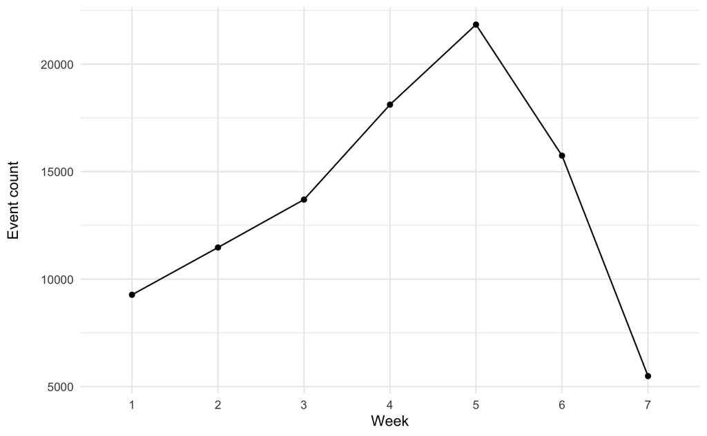

```r
table(events$course_week) |> as.data.frame() -> events_per_week

ggplot(events_per_week, aes(x = Var1, y = Freq, group=1)) +
  geom_line() + geom_point() +
  labs(x = "Week", y = "Event count\n") +
  theme_minimal()
```

Let’s now examine the character variable that represents different types of learning-related actions

```r
table(events$action)|> prop.table() |> round(digits = 3)
```

```
Applications   Assignment  Course_view       Ethics     Feedback      General   Group_work
       0.008        0.077        0.264        0.011        0.033        0.035        0.342
Instructions     La_types   Practicals       Social       Theory
       0.068        0.020        0.105        0.023        0.014
```

Some of these actions refer to individual course topics, that is, to the access to lecture materials on distinct course topics. These are: General, Applications, Theory, Ethics, Feedback, La_types. We will mark them all as “Lecture”, both to reduce the level of granularity, and to avoid mixture of activity types and activity topics

```r
course_topics <- c("General", "Applications", "Theory",  "Ethics", "Feedback", "La_types")

events$action = ifelse(test = events$action %in% course_topics,
                       yes = "Lecture",
                       no = events$action)
```

```r
table(events$action)|> prop.table() |> round(digits = 3)
```

```
  Assignment  Course_view   Group_work Instructions      Lecture   Practicals       Social
       0.077        0.264        0.342        0.068        0.121        0.105        0.023
```

Before moving to the feature engineering, let’s also prepare the outcome variable

### Examine grades data

Examine the summary statistics and distribution of the final grade

```r
summary(grades$grade)
```

```
   Min. 1st Qu.  Median    Mean 3rd Qu.    Max.
  0.000   5.666   7.954   7.254   9.006  10.000
```

We’ll add *course_outcome* as a binary variable indicating if a student had a good or weak course outcome. Students whose final grade is above 50th percentile (median) will be considered as having good course outcome (HIGH), the rest will be considered as having weak course outcome (LOW)

```r
grades$course_outcome = ifelse(test=grades$grade > median(grades$grade), yes = "High", no = "Low")
grades$course_outcome = as.factor(grades$course_outcome)
```

```r
table(grades$course_outcome)
```

```
High  Low
  65   65
```

This gives us a perfectly balanced data set for the outcome prediction (classification) task.

As done before, we remove the variable we used for creating the outcome variable

```r
grades$grade <- NULL
```

Save pre-processed data

```r
saveRDS(grades, paste(data_dir, "grades_preprocessed.RDS", sep='/'))
saveRDS(events, paste(data_dir, "events_preprocessed.RDS", sep='/'))
```

## Feature creation (engineering)

If pre-processing not done, load the pre-processed data

```r
# grades = readRDS(paste(data_dir, "grades_preprocessed.RDS", sep='/'))
# events = readRDS(paste(data_dir, "events_preprocessed.RDS", sep='/'))
```

We will create the following features for each student:

- Number of active days, where active days are days with at least one learning action
- Average number of actions per day (considering active days only)
- Average time distance between two consecutive active days
- Total number of each type of learning actions

Since the intention is to create a prediction model based on the first few weeks of the logged course data - say, **first three weeks** - we will start by creating a subset of the `events` data that includes only logged actions from the first three course weeks:

```r
events_subset = events[events$course_week <= 3, ]
```

```r
dim(events_subset)
```

```
[1] 34441     4
```

1. Compute the number of active days (= days with at least one learning action)

To compute the number of active days, we need to add the date variable

```r
events_subset$active_day = date(events_subset$dt)

events_subset[sample(1:nrow(events_subset), 10), c("dt", "active_day")]
```

|  | dt | active_day |
| --- | --- | --- |
| 42383 | 2019-09-26 14:55:26 | 2019-09-26 |
| 22690 | 2019-09-21 16:07:04 | 2019-09-21 |
| 64780 | 2019-09-14 11:30:37 | 2019-09-14 |
| 58039 | 2019-09-17 06:56:03 | 2019-09-17 |
| 6034 | 2019-09-28 16:23:48 | 2019-09-28 |
| 12793 | 2019-09-16 17:32:57 | 2019-09-16 |
| 78168 | 2019-09-26 21:36:52 | 2019-09-26 |
| 53807 | 2019-09-27 11:37:15 | 2019-09-27 |
| 89403 | 2019-09-25 21:00:23 | 2019-09-25 |
| 26223 | 2019-09-17 10:47:21 | 2019-09-17 |

Now, let’s compute the number of active days per student

```r
events_subset |>
  group_by(user) |>
  summarise(adays_cnt = n_distinct(active_day)) -> active_days_count
```

```r
head(active_days_count)
```

| user | adays_cnt |
| --- | --- |
| 00a05cc62 | 7 |
| 042b07ba1 | 7 |
| 046c35846 | 3 |
| 05b604102 | 3 |
| 0604ff3d3 | 4 |
| 077584d71 | 17 |

```r
summary(active_days_count$adays_cnt)
```

```
   Min. 1st Qu.  Median    Mean 3rd Qu.    Max.
   3.00    6.00   10.00   10.55   14.00   20.00
```

2. Next, compute average number of actions per active day

First, we’ll compute the number of actions per user per (active) day

```r
events_subset |> count(user, active_day) -> cnt_per_user_aday

head(cnt_per_user_aday, 10)
```

|  | user | active_day | n |
| --- | --- | --- | --- |
| 1 | 00a05cc62 | 2019-09-09 | 10 |
| 2 | 00a05cc62 | 2019-09-11 | 13 |
| 3 | 00a05cc62 | 2019-09-14 | 6 |
| 4 | 00a05cc62 | 2019-09-15 | 14 |
| 5 | 00a05cc62 | 2019-09-20 | 35 |
| 6 | 00a05cc62 | 2019-09-27 | 7 |
| 7 | 00a05cc62 | 2019-09-28 | 9 |
| 8 | 042b07ba1 | 2019-09-12 | 9 |
| 9 | 042b07ba1 | 2019-09-13 | 70 |
| 10 | 042b07ba1 | 2019-09-17 | 47 |

Then, we’ll average the number of action (n) for each user

```r
cnt_per_user_aday |>
  group_by(user) |>
  summarise(avg_action_cnt = median(n)) -> avg_cnt_per_aday
```

```r
head(avg_cnt_per_aday)
```

| user | avg_action_cnt |
| --- | --- |
| 00a05cc62 | 10 |
| 042b07ba1 | 57 |
| 046c35846 | 19 |
| 05b604102 | 19 |
| 0604ff3d3 | 29 |
| 077584d71 | 11 |

3. Average time distance between two consecutive active days

We will do this in a step-wise manner to make the computation clearer

First, reduce the data set to distinct active days for each user. The rationale: since we need to compute time distance between consecutive active days, we need just one occurrence of each active day

```r
events_subset |>
  distinct(user, active_day) |>
  arrange(user, active_day) -> distinct_user_aday
```

```r
head(distinct_user_aday, 10)
```

|  | user | active_day |
| --- | --- | --- |
| 1 | 00a05cc62 | 2019-09-09 |
| 2 | 00a05cc62 | 2019-09-11 |
| 3 | 00a05cc62 | 2019-09-14 |
| 4 | 00a05cc62 | 2019-09-15 |
| 5 | 00a05cc62 | 2019-09-20 |
| 6 | 00a05cc62 | 2019-09-27 |
| 7 | 00a05cc62 | 2019-09-28 |
| 8 | 042b07ba1 | 2019-09-12 |
| 9 | 042b07ba1 | 2019-09-13 |
| 10 | 042b07ba1 | 2019-09-17 |

Next, add a variable that will for each active day store the immediate previous active day (if it exists) Note the use of two new functions: i) `mutate` allows for creating new variables in a data frame; ii) `lag` returns the value of the given variable lagged for the given number of steps, by default 1

```r
distinct_user_aday |>
  group_by(user) |>
  mutate(prev_active_day = lag(active_day)) -> distinct_user_aday

head(distinct_user_aday, 10)
```

| user | active_day | prev_active_day |
| --- | --- | --- |
| 00a05cc62 | 2019-09-09 |  |
| 00a05cc62 | 2019-09-11 | 2019-09-09 |
| 00a05cc62 | 2019-09-14 | 2019-09-11 |
| 00a05cc62 | 2019-09-15 | 2019-09-14 |
| 00a05cc62 | 2019-09-20 | 2019-09-15 |
| 00a05cc62 | 2019-09-27 | 2019-09-20 |
| 00a05cc62 | 2019-09-28 | 2019-09-27 |
| 042b07ba1 | 2019-09-12 |  |
| 042b07ba1 | 2019-09-13 | 2019-09-12 |
| 042b07ba1 | 2019-09-17 | 2019-09-13 |

Now we can add a variable for the time difference between an active day and the immediate previous (active) day. We compute this for each user separately.

```r
distinct_user_aday |>
  group_by(user) |>
  mutate(aday_diff = ifelse(is.na(prev_active_day),
                            yes = NA,
                            no = difftime(active_day, prev_active_day, units = "days"))) -> distinct_user_aday
```

```r
head(distinct_user_aday, 10)
```

| user | active_day | prev_active_day | aday_diff |
| --- | --- | --- | --- |
| 00a05cc62 | 2019-09-09 |  | NA |
| 00a05cc62 | 2019-09-11 | 2019-09-09 | 2 |
| 00a05cc62 | 2019-09-14 | 2019-09-11 | 3 |
| 00a05cc62 | 2019-09-15 | 2019-09-14 | 1 |
| 00a05cc62 | 2019-09-20 | 2019-09-15 | 5 |
| 00a05cc62 | 2019-09-27 | 2019-09-20 | 7 |
| 00a05cc62 | 2019-09-28 | 2019-09-27 | 1 |
| 042b07ba1 | 2019-09-12 |  | NA |
| 042b07ba1 | 2019-09-13 | 2019-09-12 | 1 |
| 042b07ba1 | 2019-09-17 | 2019-09-13 | 4 |

Finally, we can compute, for each user, the average (median) time distance between any two consecutive active days

```r
distinct_user_aday |>
  group_by(user) |>
  summarise(avg_aday_diff = median(aday_diff, na.rm=T)) -> avg_aday_time_diff
```

```r
head(avg_aday_time_diff, 10)
```

| user | avg_aday_diff |
| --- | --- |
| 00a05cc62 | 2.5 |
| 042b07ba1 | 2.5 |
| 046c35846 | 8.0 |
| 05b604102 | 8.0 |
| 0604ff3d3 | 3.0 |
| 077584d71 | 1.0 |
| 081b100cf | 2.0 |
| 0857b3d8e | 1.0 |
| 0ec99ce96 | 1.5 |
| 0ef305578 | 1.0 |

```r
summary(avg_aday_time_diff$avg_aday_diff)
```

```
   Min. 1st Qu.  Median    Mean 3rd Qu.    Max.
  1.000   1.000   1.250   1.945   2.500   8.000
```

4. Total number of each type of learning action

We can easily compute, for each student, the number of actions of distinct types:

```r
events_subset |>
  count(user, action) -> counts_per_user
```

```r
head(counts_per_user)
```

|  | user | action | n |
| --- | --- | --- | --- |
| 1 | 00a05cc62 | Course_view | 36 |
| 2 | 00a05cc62 | Group_work | 18 |
| 3 | 00a05cc62 | Instructions | 9 |
| 4 | 00a05cc62 | Lecture | 11 |
| 5 | 00a05cc62 | Practicals | 16 |
| 6 | 00a05cc62 | Social | 4 |

However, this format of the computed action counts cannot serve as the input for a classification algorithm. What we need is a data frame with columns corresponding to distinct types of actions (e.g., Course_view, Group_work, Lecture, …) and values of those columns being counts of students’ actions of the given type. In particular, we want unique values of the `action` column to be the columns in a data frame, whereas values of the column `n` should be used to populate those columns.

This is, in fact, a very frequent problem and a solution is readily available from the the *tidyr* package. It is known as transforming data from the *long format* (the one given above) to the *wide format* (our target, see the output of the cell below). The name *long format* refers to (relatively) small number of columns and (relatively) large number of rows. On the other hand, the name *wide format* refers to the opposite - (relatively) large number of columns and (relatively) small number of rows.

```r
library(tidyr)
```

The function we’ll use is `pivot_wider`

```r
?pivot_wider
```

```r
counts_per_user |>
  pivot_wider(id_cols = user,
              names_from = action,
              values_from = n,
              values_fill = 0) -> counts_per_user_wide
```

```r
head(counts_per_user_wide)
```

| user | Course_view | Group_work | Instructions | Lecture | Practicals | Social | Assignment |
| --- | --- | --- | --- | --- | --- | --- | --- |
| 00a05cc62 | 36 | 18 | 9 | 11 | 16 | 4 | 0 |
| 042b07ba1 | 113 | 93 | 36 | 15 | 32 | 26 | 5 |
| 046c35846 | 22 | 1 | 6 | 32 | 19 | 0 | 1 |
| 05b604102 | 20 | 1 | 7 | 31 | 18 | 0 | 4 |
| 0604ff3d3 | 32 | 40 | 4 | 3 | 23 | 0 | 0 |
| 077584d71 | 107 | 98 | 34 | 48 | 46 | 14 | 3 |

Compare the dimensions of the long and wide formats (of the same data):

```r
print(paste("Long format:", nrow(counts_per_user), "rows and", ncol(counts_per_user), "columns"))
```

```
[1] "Long format: 844 rows and 3 columns"
```

```r
print(paste("Wide format:", nrow(counts_per_user_wide), "rows and", ncol(counts_per_user_wide), "columns"))
```

```
[1] "Wide format: 128 rows and 8 columns"
```

Now that we have computed all the features, we should integrate them into one data frame. This can be easily done using the `inner_join` f. from *dplyr* package. This function works like the inner join operation in data bases.

```r
active_days_count |>
  inner_join(avg_cnt_per_aday) |>
  inner_join(avg_aday_time_diff) |>
  inner_join(counts_per_user_wide) -> feature_set
```

Note that here we didn’t specify the column(s) to be used for joining the data frames and the `inner_join` function used the column that the two data frames it was joining had in common (in this case the `user` column)

```r
head(feature_set, 10)
```

| user | adays_cnt | avg_action_cnt | avg_aday_diff | Course_view | Group_work | Instructions | Lecture | Practicals | Social | Assignment |
| --- | --- | --- | --- | --- | --- | --- | --- | --- | --- | --- |
| 00a05cc62 | 7 | 10.0 | 2.5 | 36 | 18 | 9 | 11 | 16 | 4 | 0 |
| 042b07ba1 | 7 | 57.0 | 2.5 | 113 | 93 | 36 | 15 | 32 | 26 | 5 |
| 046c35846 | 3 | 19.0 | 8.0 | 22 | 1 | 6 | 32 | 19 | 0 | 1 |
| 05b604102 | 3 | 19.0 | 8.0 | 20 | 1 | 7 | 31 | 18 | 0 | 4 |
| 0604ff3d3 | 4 | 29.0 | 3.0 | 32 | 40 | 4 | 3 | 23 | 0 | 0 |
| 077584d71 | 17 | 11.0 | 1.0 | 107 | 98 | 34 | 48 | 46 | 14 | 3 |
| 081b100cf | 10 | 27.5 | 2.0 | 81 | 88 | 34 | 9 | 37 | 4 | 3 |
| 0857b3d8e | 17 | 29.0 | 1.0 | 126 | 187 | 32 | 56 | 29 | 38 | 9 |
| 0ec99ce96 | 9 | 11.0 | 1.5 | 74 | 36 | 18 | 27 | 26 | 2 | 1 |
| 0ef305578 | 13 | 13.0 | 1.0 | 107 | 140 | 33 | 37 | 58 | 16 | 24 |

Add the outcome variable

```r
feature_set |>
  inner_join(grades) -> feature_set
```

Check the structure and completeness of the resulting data set

```r
glimpse(feature_set)
```

```
Rows: 128
Columns: 12
$ user           <chr> "00a05cc62", "042b07ba1", "046c35846", "05b604102", "0604ff3d3", "07758…
$ adays_cnt      <int> 7, 7, 3, 3, 4, 17, 10, 17, 9, 13, 3, 13, 7, 7, 5, 6, 3, 13, 7, 9, 7, 9,…
$ avg_action_cnt <dbl> 10.0, 57.0, 19.0, 19.0, 29.0, 11.0, 27.5, 29.0, 11.0, 13.0, 40.0, 13.0,…
$ avg_aday_diff  <dbl> 2.5, 2.5, 8.0, 8.0, 3.0, 1.0, 2.0, 1.0, 1.5, 1.0, 7.0, 1.0, 1.5, 2.5, 1…
$ Course_view    <int> 36, 113, 22, 20, 32, 107, 81, 126, 74, 107, 45, 75, 68, 35, 25, 46, 23,…
$ Group_work     <int> 18, 93, 1, 1, 40, 98, 88, 187, 36, 140, 25, 115, 58, 19, 20, 10, 1, 139…
$ Instructions   <int> 9, 36, 6, 7, 4, 34, 34, 32, 18, 33, 18, 49, 18, 9, 16, 41, 9, 35, 17, 1…
$ Lecture        <int> 11, 15, 32, 31, 3, 48, 9, 56, 27, 37, 9, 34, 14, 12, 48, 2, 30, 36, 1, …
$ Practicals     <int> 16, 32, 19, 18, 23, 46, 37, 29, 26, 58, 3, 27, 5, 16, 15, 17, 17, 56, 2…
$ Social         <int> 4, 26, 0, 0, 0, 14, 4, 38, 2, 16, 8, 13, 19, 3, 3, 7, 0, 19, 2, 2, 3, 1…
$ Assignment     <int> 0, 5, 1, 4, 0, 3, 3, 9, 1, 24, 1, 17, 11, 0, 2, 16, 1, 25, 0, 1, 0, 3, …
$ course_outcome <fct> Low, Low, Low, Low, Low, High, High, High, Low, High, High, High, Low, …
```

```r
all(complete.cases(feature_set))
```

```
[1] TRUE
```

### Examine feature relevance

Examine the relevance of features for the prediction of the outcome variable

Let’s first recall how we can do it for one continuous variable

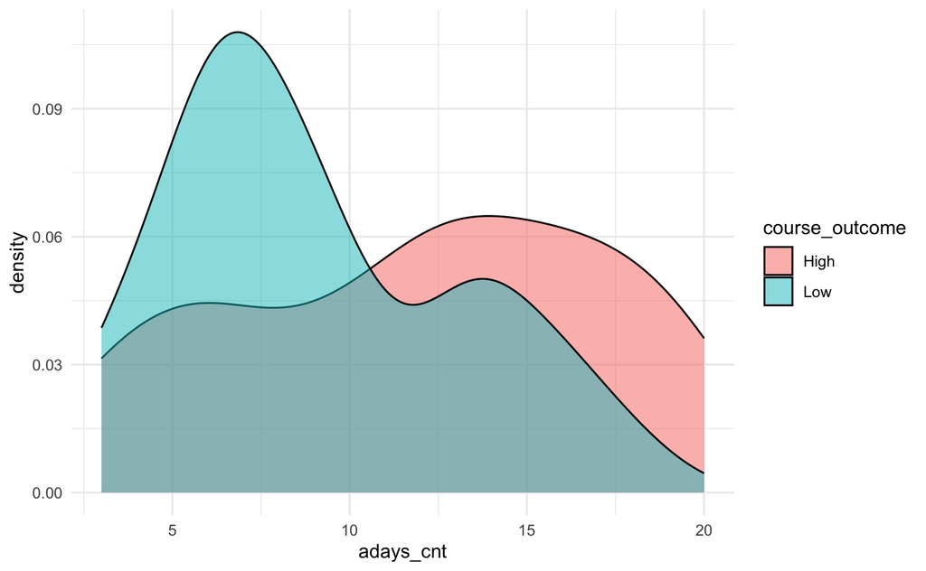

```r
ggplot(feature_set,
       aes(x = adays_cnt, fill=course_outcome)) +
  geom_density(alpha=0.5) +
  theme_minimal()
```

Clearly, the number of active days is relevant for predicting the course outcome, since the plot indicates that students with more active days tend to have high course performance

Now, do for all features at once:

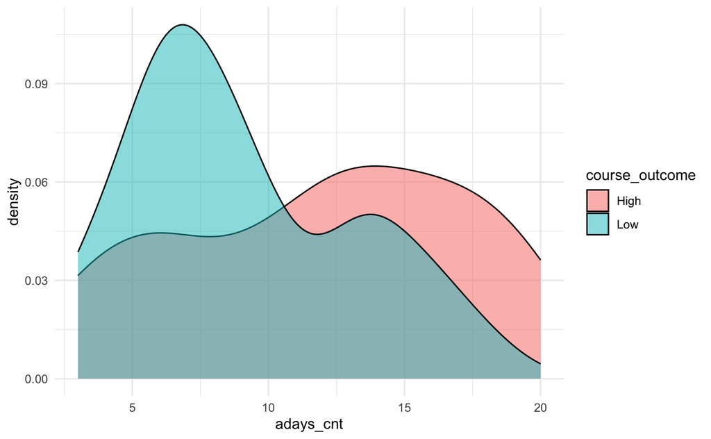

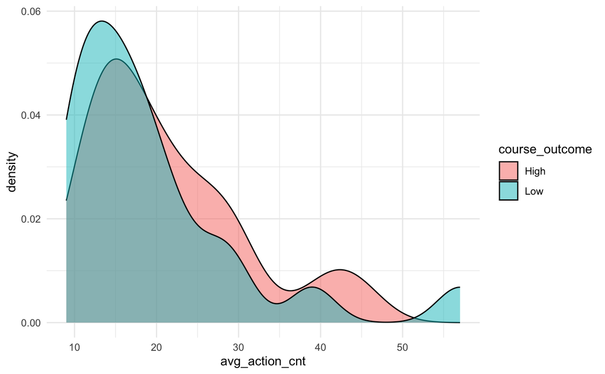

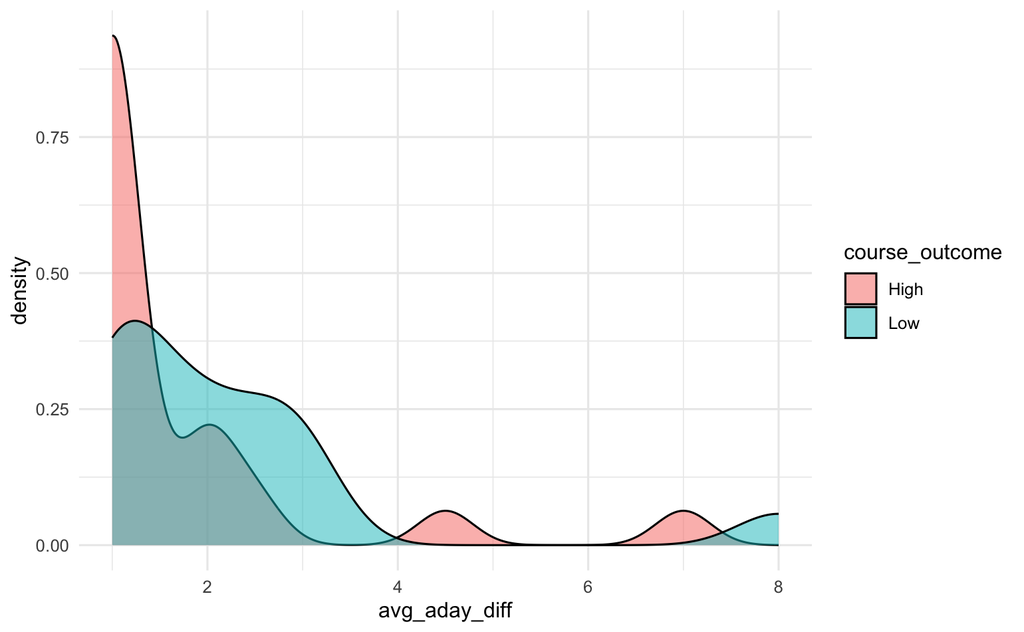

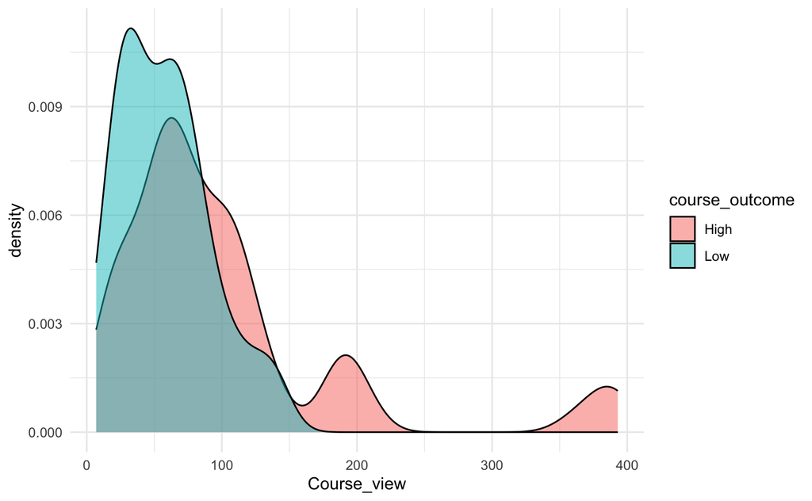

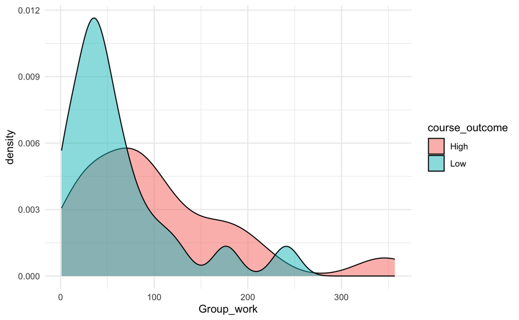

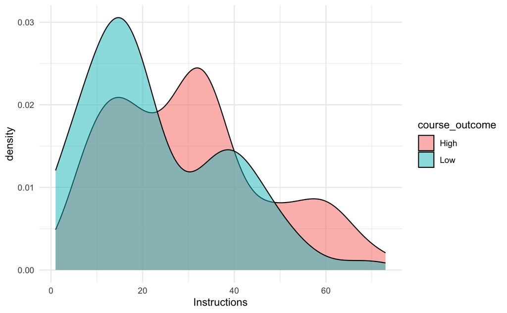

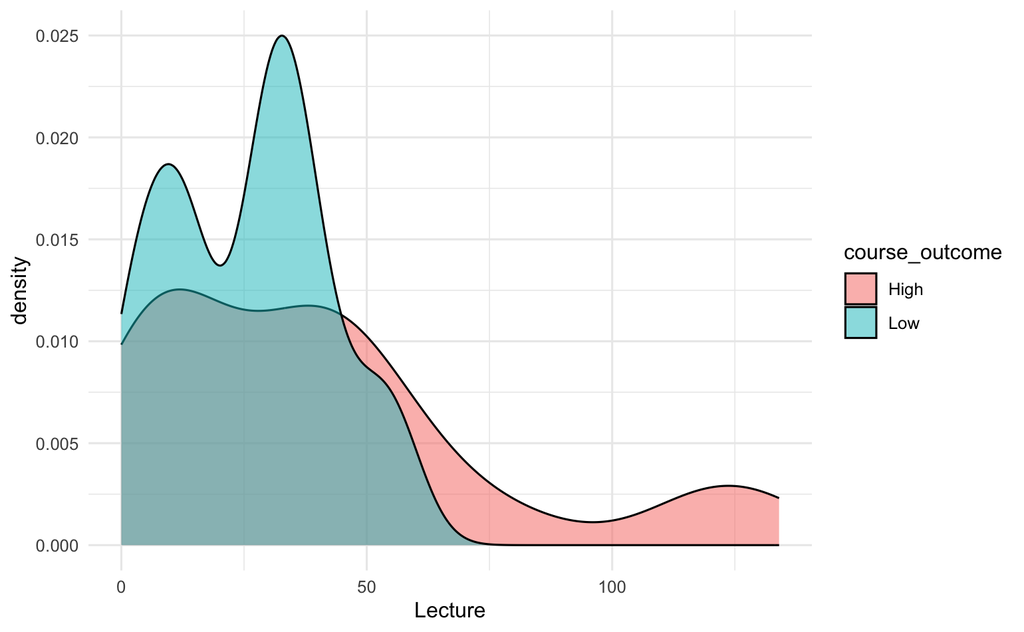

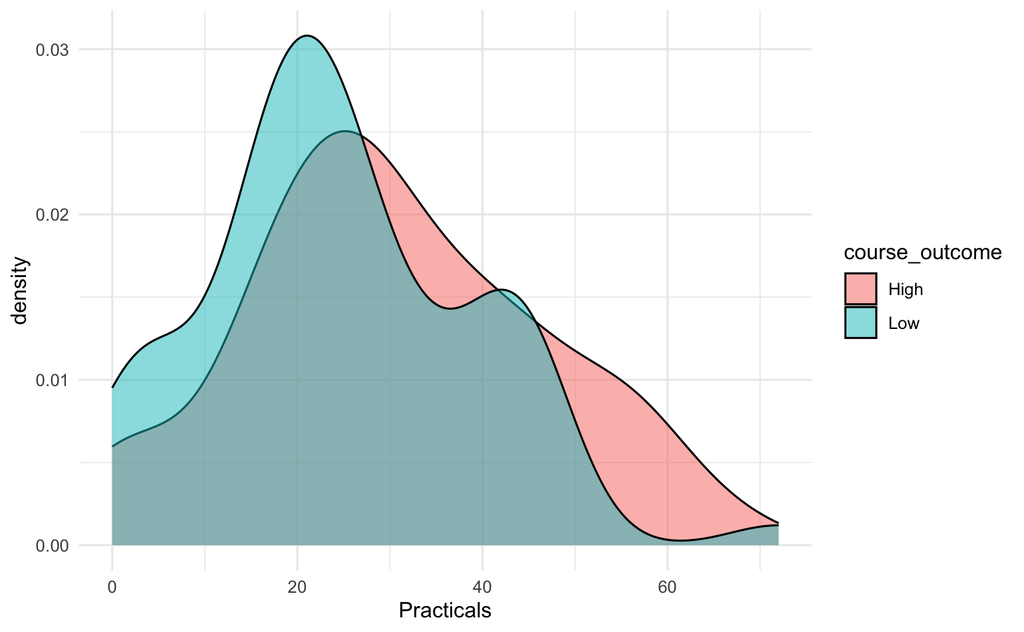

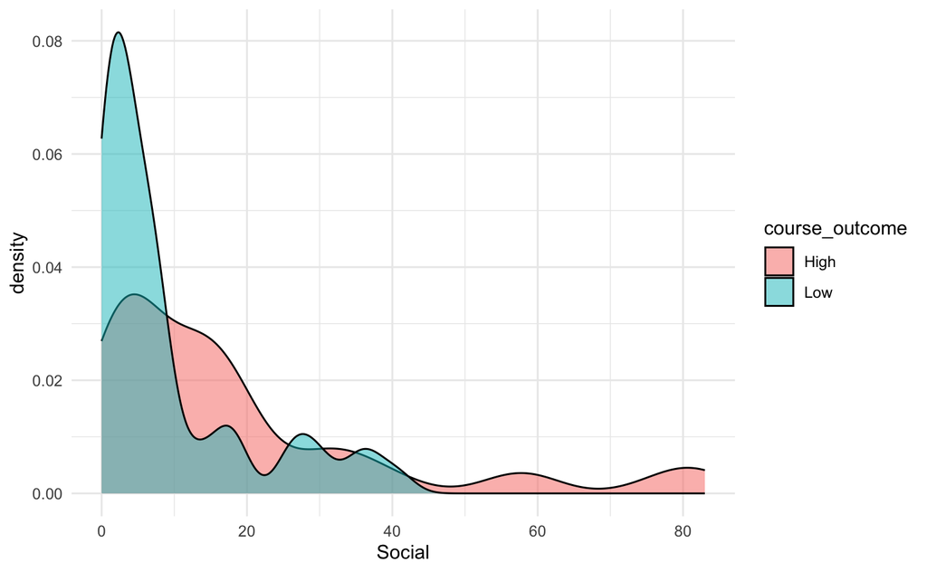

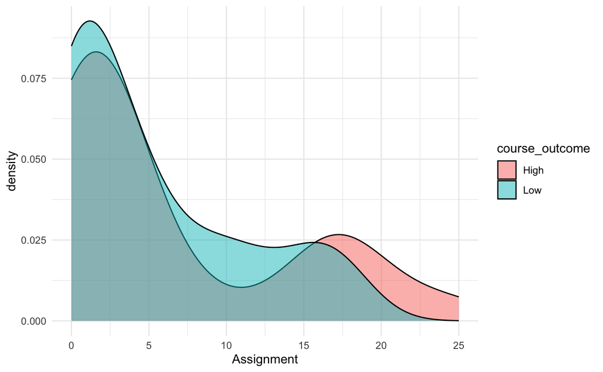

```r
feature_names <- colnames(feature_set)[2:11]

# Note: the notation .data[[fn]] in the code below allows us to access a column from the 'current' data frame
# (in this case, final_ds) with the name given as the input variable of the function (fn)
lapply(feature_names,
       function(fn) {
         ggplot(feature_set, aes(x = .data[[fn]], fill=course_outcome)) +
           geom_density(alpha=0.5) +
           theme_minimal()
       })
```

The plots suggest that all features - except for `avg_action_cnt`, `Assignment` and maybe `Lecture` - are potentially relevant for predicting the course outcome.

```r
feature_set |>
  select(-c(Assignment, avg_action_cnt)) -> final_ds
```

We have now completed the feature engineering and selection work. Since we have a small number of observations and all features are numerical, we can use kNN. As this is something we have done before, the rest of the code will not be commented in detail.

## Predictive modeling

Load additional R packages required for model building and evaluation

```r
library(caret)
library(class)
```

Recall that kNN requires that all features have roughly equal value ranges. So, we will first check that and do rescalling if value ranges notably differ.

```r
summary(final_ds)
```

```
     user             adays_cnt     avg_aday_diff    Course_view       Group_work
 Length:128         Min.   : 3.00   Min.   :1.000   Min.   :  7.00   Min.   :  1.00
 Class :character   1st Qu.: 6.00   1st Qu.:1.000   1st Qu.: 35.75   1st Qu.: 30.75
 Mode  :character   Median :10.00   Median :1.250   Median : 65.00   Median : 58.50
                    Mean   :10.55   Mean   :1.945   Mean   : 79.64   Mean   : 82.87
                    3rd Qu.:14.00   3rd Qu.:2.500   3rd Qu.: 97.25   3rd Qu.:110.50
                    Max.   :20.00   Max.   :8.000   Max.   :393.00   Max.   :357.00
  Instructions      Lecture         Practicals       Social      course_outcome
 Min.   : 1.00   Min.   :  0.00   Min.   : 0.0   Min.   : 0.00   High:65
 1st Qu.:14.00   1st Qu.: 11.00   1st Qu.:17.0   1st Qu.: 2.75   Low :63
 Median :23.00   Median : 30.50   Median :25.0   Median : 7.00
 Mean   :26.48   Mean   : 32.99   Mean   :27.6   Mean   :13.73
 3rd Qu.:35.25   3rd Qu.: 42.50   3rd Qu.:39.5   3rd Qu.:17.25
 Max.   :73.00   Max.   :134.00   Max.   :72.0   Max.   :83.00
```

Clearly, rescalling is required. We need to determine how to do it…

```r
apply(final_ds[,c(2:9)], 2, function(x) length(boxplot.stats(x)$out))
```

```
    adays_cnt avg_aday_diff   Course_view    Group_work  Instructions       Lecture
            0             7             7             7             2             7
   Practicals        Social
            0             9
```

```r
apply(final_ds[,c(2:9)], 2,
      function(x) scale(x, center = median(x), scale = IQR(x))) |> as.data.frame() -> final_rescaled
```

```r
summary(final_rescaled)
```

```
   adays_cnt        avg_aday_diff      Course_view        Group_work       Instructions
 Min.   :-0.87500   Min.   :-0.1667   Min.   :-0.9431   Min.   :-0.7210   Min.   :-1.0353
 1st Qu.:-0.50000   1st Qu.:-0.1667   1st Qu.:-0.4756   1st Qu.:-0.3480   1st Qu.:-0.4235
 Median : 0.00000   Median : 0.0000   Median : 0.0000   Median : 0.0000   Median : 0.0000
 Mean   : 0.06836   Mean   : 0.4635   Mean   : 0.2381   Mean   : 0.3055   Mean   : 0.1640
 3rd Qu.: 0.50000   3rd Qu.: 0.8333   3rd Qu.: 0.5244   3rd Qu.: 0.6520   3rd Qu.: 0.5765
 Max.   : 1.25000   Max.   : 4.5000   Max.   : 5.3333   Max.   : 3.7429   Max.   : 2.3529
    Lecture           Practicals          Social
 Min.   :-0.96825   Min.   :-1.1111   Min.   :-0.4828
 1st Qu.:-0.61905   1st Qu.:-0.3556   1st Qu.:-0.2931
 Median : 0.00000   Median : 0.0000   Median : 0.0000
 Mean   : 0.07912   Mean   : 0.1156   Mean   : 0.4639
 3rd Qu.: 0.38095   3rd Qu.: 0.6444   3rd Qu.: 0.7069
 Max.   : 3.28571   Max.   : 2.0889   Max.   : 5.2414
```

Add the outcome variable to complete the data set

```r
final_rescaled$course_outcome <- final_ds$course_outcome
```

Split the data into training and test sets

```r
set.seed(2024)
for_training = createDataPartition(final_rescaled$course_outcome, p = 0.8, list = FALSE)
train_data = final_rescaled[for_training,]
test_data = final_rescaled[-for_training,]
```

Use cross-validation to determine the optimal value for K (the number of nearest neighbours to consider)

```r
k_grid <- expand.grid(.k = seq(3, 15, 2))
ctrl <- trainControl(method = "CV", number = 10)

set.seed(2024)
knn_cv <- train(x = train_data[,-9],
                y = train_data$course_outcome,
                method = "knn",
                tuneGrid = k_grid,
                trControl = ctrl)

knn_cv
```

```
k-Nearest Neighbors

103 samples
  8 predictor
  2 classes: 'High', 'Low'

No pre-processing
Resampling: Cross-Validated (10 fold)
Summary of sample sizes: 91, 93, 93, 93, 93, 93, ...
Resampling results across tuning parameters:

  k   Accuracy   Kappa
   3  0.6721212  0.3468817
   5  0.6146970  0.2304372
   7  0.5863636  0.1694915
   9  0.6245455  0.2467797
  11  0.6145455  0.2267797
  13  0.5945455  0.1867797
  15  0.6336364  0.2666667

Accuracy was used to select the optimal model using the largest value.
The final value used for the model was k = 3.
```

Make predictions on the test set using the optimal value for K

```r
knn_pred = knn(train = train_data[,-9],
               test = test_data[,-9],
               cl = train_data$course_outcome,
               k = knn_cv$bestTune$k)
```

Evaluate the predictions using the standard set of evaluation measures

```r
source("util.R")
```

```r
cm <- table(true = test_data$course_outcome,
            predicted = knn_pred)

cm
```

```
      predicted
true   High Low
  High   11   2
  Low     3   9
```

```r
compute_eval_measures_v1(cm)
```

```
 accuracy precision    recall        F1
   0.8000    0.8182    0.7500    0.7826
```

The results suggest that already early in this course, it is possible to fairly well predict students at risk of low performance (positive class in this case). For example, out of all those who eventually showed low course performance, we have correctly identified 75% of them. Likewise, when predicting someone as having low course performance, we were correct in 82% of cases.